# Peer-graded Assignment: Course Project 1

Miguel Santana

2023-02-20

## Loading and preprocessing the data

```r
# Some libraries to run all the code
library(dplyr)
```

```r
library(ggplot2)
```

```r
# Reading the data from the 'activity.csv' file.
activity <- na.omit(read.csv(file = 'activity.csv'))
activity$date <- as.Date(activity$date)
head(activity)
```

```
##     steps       date interval
## 289     0 2012-10-02        0
## 290     0 2012-10-02        5
## 291     0 2012-10-02       10
## 292     0 2012-10-02       15
## 293     0 2012-10-02       20
## 294     0 2012-10-02       25
```

## What is mean total number of steps taken per day?

**Objectives:**

1. Make a histogram of the total number of steps taken each day
2. Calculate and report the **mean** and **median** total number of steps taken per day

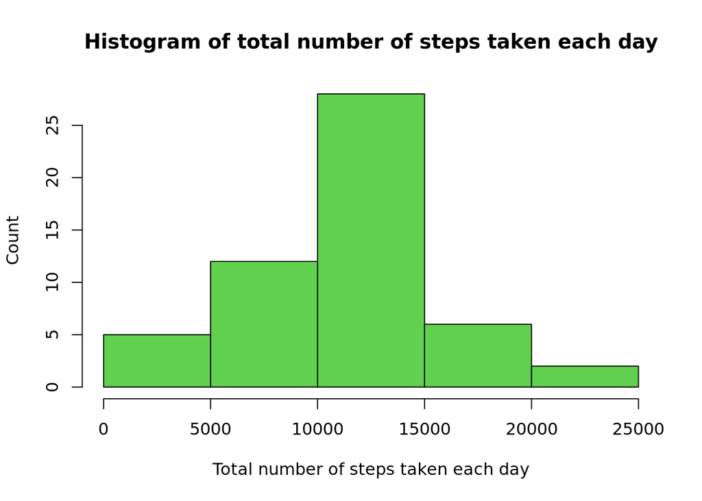

```r
# Group 'activity' data by date
by_day <- group_by(activity, date)
# Summarise the sum of steps
steps_by_day <- summarise(by_day, total = sum(steps))

hist(steps_by_day$total,
     xlab="Total number of steps taken each day",
     ylab="Count",
     main="Histogram of total number of steps taken each day",
     col=3)
```

```r
mean_steps <- mean(steps_by_day$total)
median_steps <- median(steps_by_day$total)
```

## What is the average daily activity pattern?

**Objectives:**

1. Make a time series plot (i.e. `type = "l"`) of the 5-minute interval (x-axis) and the average number of steps taken, averaged across all days (y-axis)
2. Which 5-minute interval, on average across all the days in the dataset, contains the maximum number of steps?

[figure not shown]

```r
# Group data by 5 minute interval
activity_interval <- group_by(activity, interval)
# Summarize the average number of steps in that interval
five_average_by_day <- summarise(activity_interval, total = sum(steps))

# Make an average activity plot
plot(five_average_by_day$interval, five_average_by_day$total,
     type="l",
     xlab="Interval",
     ylab="Average steps taken",
     main="Average steps taken during 5 minute interval")
```

```r
max_step_interval <- five_average_by_day$interval[which.max(five_average_by_day$total)]
```

The highest step count happened at interval 835.

## Imputing missing values

**Objectives:**

1. Calculate and report the total number of missing values in the dataset (i.e. the total number of rows with `NA`s)
2. Devise a strategy for filling in all of the missing values in the dataset. The strategy does not need to be sophisticated. For example, you could use the mean/median for that day, or the mean for that 5-minute interval, etc.
3. Create a new dataset that is equal to the original dataset but with the missing data filled in.
4. Make a histogram of the total number of steps taken each day and Calculate and report the **mean** and **median** total number of steps taken per day. Do these values differ from the estimates from the first part of the assignment? What is the impact of imputing missing data on the estimates of the total daily number of steps?

```r
# Sum the number of missing values
missing <- sum(is.na(read.csv(file = 'activity.csv')$steps))
```

There are 2304 NA values in the raw data set.

```r
# Create a filled in data set by assigning the average value
# for that time interval if an NA is found.
fill_data <- read.csv(file = 'activity.csv')
for (i in 1:nrow(fill_data)) {
    if (is.na(fill_data$steps[i])) {
        # Find the index value for when the interval matches the average
        ndx <- which(fill_data$interval[i] == five_average_by_day$interval)
        # Assign the value to replace the NA
        fill_data$steps[i] <- five_average_by_day[ndx,]$total
    }
}

# Make sure the date variable is still a date.
fill_data$date <- as.Date(fill_data$date)
```

Plot the new filled data set with a histogram:

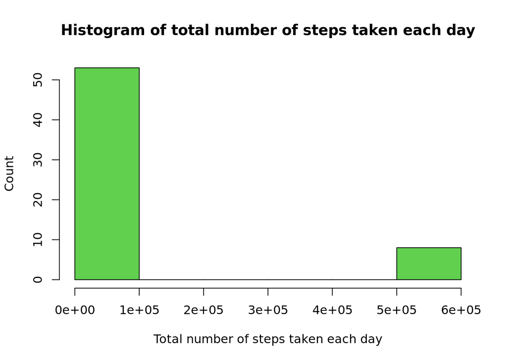

```r
# Group data by date, and summarise the sum of steps
fill_steps_per_day <- fill_data %>%
    group_by(date) %>%
    summarise(total=sum(steps))

# Show histogram of steps per day
hist(fill_steps_per_day$total,
     xlab="Total number of steps taken each day",
     ylab="Count",
     main="Histogram of total number of steps taken each day",
     col=3)
```

```r
fill_mean_steps <- mean(fill_steps_per_day$total)
fill_median_steps <- median(fill_steps_per_day$total)
```

## Are there differences in activity patterns between weekdays and weekends?

**Objectives:**

```r
# Make weekday variable
fill_data$day <- weekdays(fill_data$date)
# Define all days as weekdays
fill_data$day_type <- "weekday"
# Fix days that are Saturday or Sunday to be weekends
fill_data$day_type[fill_data$day %in% c("Saturday", "Sunday")] <- "weekend"
```

Calculate the average weekday steps versus average weekend steps

```r
# Group data by 5 minute interval and summarize the average
# number of steps in that interval
day_average <- fill_data %>%
    group_by(day_type, interval) %>%
    summarise(total=mean(steps))
```

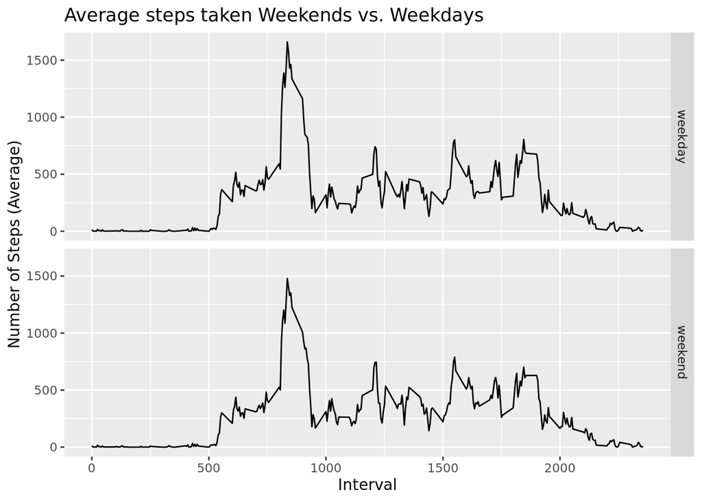

```r
qplot(interval, total, data=day_average,
      type="l",
      geom="line",
      xlab="Interval",
      ylab="Number of Steps (Average)",
      main="Average steps taken Weekends vs. Weekdays",
      facets=day_type ~ .)
```